# Análise Ambiental

Apresentação da Disciplina e  
Questão Ambiental Contemporânea

Luiz Diego Vidal Santos

## Visão Geral da Aula

### Tópicos

- 1 Apresentação da disciplina, ementa e plano de trabalho
- 2 Crise ambiental contemporânea
- 3 Degradação dos solos e escassez hídrica
- 4 Mudanças no uso da terra
- 5 Planejamento ambiental
- 6 Papel da Geografia na análise integrada

**Objetivo da Aula**

Apresentar o componente curricular e situar a análise ambiental no horizonte da crise ambiental contemporânea, demarcando o papel da Geografia na leitura integrada das relações sociedade-natureza.

# 1 - APRESENTAÇÃO DA DISCIPLINA

## O componente curricular

### Dados gerais

| Item | Detalhe |
| --- | --- |
| **Disciplina** | Análise Ambiental |
| **Carga horária** | 64 h (16 encontros) |
| **Período** | 2026.2 |
| **Modalidade** | Presencial |
| **Avaliações** | 1ª Teórica (Sem. 11) + 2ª Prática (Sem. 16) + 5 Estudos Orientados |

**Por que Análise Ambiental?**

Analisar o ambiente é articular **meio físico**, **meio biótico** e **meio antrópico** em diferentes **escalas espaço-temporais**, gerando:

- **Diagnóstico** (estado atual)
- **Prognóstico** (tendência)
- **Proposição** (intervenção)

A análise ambiental fundamenta AIA, planos de bacia, ZEE, PRAD e licenciamento.

## Estrutura do semestre

### Três blocos temáticos

[output not shown]

**Estudos Orientados (1 a 5)**

Fichamento de PORTO-GONÇALVES (nº 1, Sem. 3), MENDONÇA (nº 2, Sem. 5), SÁNCHEZ (nº 3, Sem. 6) e BERTRAND (nº 5, Sem. 9); no nº 4, análise de um EIA/RIMA público (Sem. 7). Roteiro dos fichamentos:

1. Contexto e tese central
2. Conceitos operacionais
3. Aplicação ao território de estudo
4. Crítica e síntese

# 2 - CRISE AMBIENTAL CONTEMPORÂNEA

## Antropoceno e Limites Planetários

### Marco conceitual

- **Antropoceno** (Crutzen & Stoermer, 2000): ação humana como força geomorfológica e biogeoquímica dominante.
- **Grande Aceleração** (pós-1950): aumento exponencial de população, GEE, fertilizantes e consumo hídrico.
- **Limites Planetários** (Rockström *et al.*, 2009; Steffen *et al.*, 2015): nove fronteiras de segurança do sistema Terra.

**Da crise global à crise territorial**

| Escala | Manifestação |
| --- | --- |
| **Global** | Aquecimento, acidificação oceânica |
| **Regional** | Desmatamento, escassez hídrica |
| **Local** | Voçorocas, assoreamento, contaminação |

> Seis dos nove limites já foram ultrapassados (Richardson *et al.*, 2023). A análise ambiental opera na interface entre a escala local e os drivers globais.

## Limites Planetários - diagnóstico visual

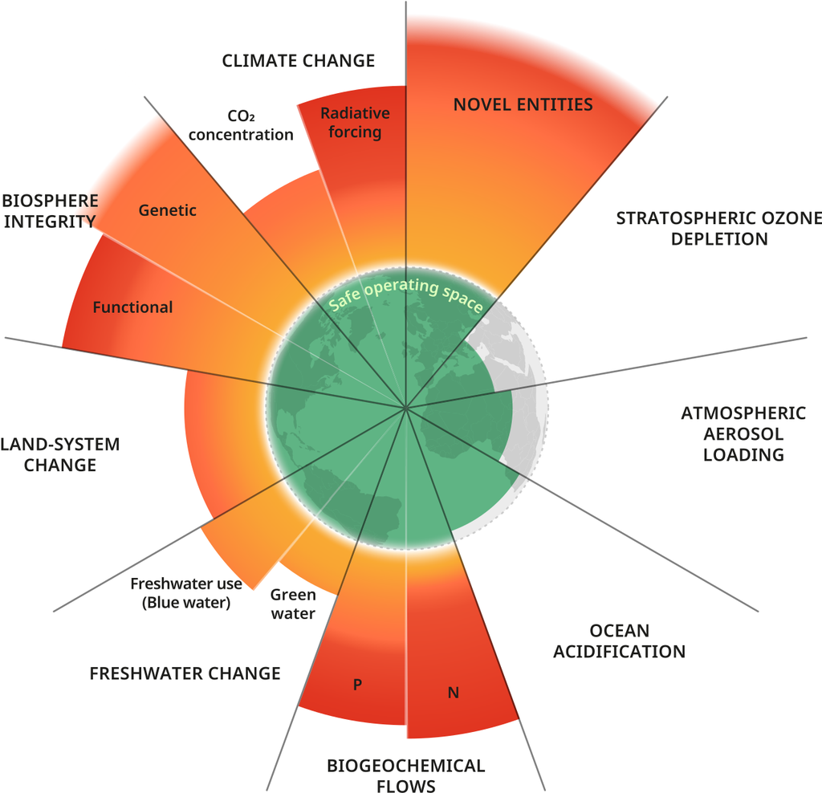

Fonte: Richardson *et al.* (2023); gráfico Azote para Stockholm Resilience Centre.

**Seis limites já ultrapassados**

- Mudança climática
- Integridade da biosfera
- Fluxos biogeoquímicos de nitrogênio e fósforo
- Mudança no uso da terra
- Mudança da água doce
- Novas entidades químicas

> O diagrama indica riscos em escala planetária; a análise ambiental os traduz em evidências e indicadores territoriais.

## Degradação dos solos e escassez hídrica

### Degradação do solo no Brasil

- ~30% dos solos cultivados têm degradação física, química ou biológica (Embrapa, FAO/GLASOD).
- Erosão hídrica subtrai bilhões de toneladas de solo/ano (perdas de C, N, P e cátions).
- **Áreas susceptíveis à desertificação (ASD)** no Semiárido: ~1,3 milhão de km² (PAN-Brasil, MMA).
- **Compactação** e **perda de MO** reduzem infiltração e elevam escoamento superficial.

[figure not shown]

### Escassez hídrica

| Vetor | Manifestação |
| --- | --- |
| **Climático** | Secas plurianuais (NE), eventos extremos |
| **Estrutural** | Distribuição assimétrica da rede hidrográfica |
| **Antrópico** | Sobreoutorga, contaminação difusa |
| **Paisagístico** | Perda de cobertura, assoreamento |

A hidrologia é uma **expressão integrada da paisagem**: solo, relevo, vegetação e uso da terra modulam infiltração, escoamento e recarga.

## Mudanças no uso da terra

### Vetores principais (Brasil)

- Expansão da fronteira agropecuária (Cerrado, MATOPIBA, Amazônia)
- Substituição de pastagens nativas por monocultivos
- Conversão de Caatinga para agricultura irrigada e mineração
- Expansão urbana periurbana (selamento, ilhas de calor)
- Mineração industrial e garimpo

**Pergunta-guia**

Que mudança de cobertura ou de manejo ajuda a explicar a alteração observada no solo, na drenagem ou na vegetação?

**Sequência de análise**

1. Identifique o **uso e a cobertura** atual.
2. Compare com evidências de **mudança no tempo**.
3. Relacione a mudança a **processos** (erosão, escoamento, assoreamento).
4. Selecione um **indicador** para acompanhar a resposta.

## Consequências na paisagem

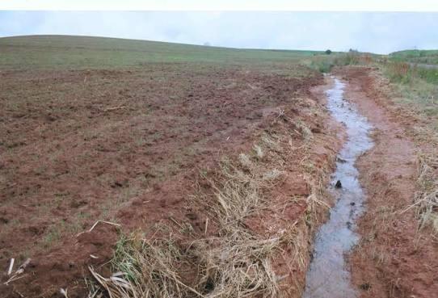

> Observe a distribuição de solo exposto, vegetação, canais de drenagem e áreas de uso produtivo.

### O que a mudança pode produzir

- Fragmentação de habitat - Perda de conectividade hidrossedimentológica - Redução do estoque de carbono no solo
- Aumento das feições erosivas

**Do uso ao processo**

Uma mudança de cobertura não é, por si só, o impacto. Ela altera fluxos de água, solo, matéria e organismos, que precisam ser demonstrados no diagnóstico.

## Monitorar a mudança: da paisagem ao dado

**O dado não substitui a leitura de campo**

Imagens, mapas e séries temporais ajudam a localizar mudanças. A confirmação exige observar o processo no território e registrar seus indicadores.

### Três perguntas operacionais

- **Onde** a mudança está concentrada?
- **Quando** ela se intensificou?
- **Que processo ambiental** ela pode alterar?

### Bases de monitoramento livres

| Base | O que oferece |
| --- | --- |
| **MapBiomas** | Coleções anuais de uso/cobertura desde 1985 (Brasil e países da Pan-Amazônia) |
| **PRODES/DETER (INPE)** | Desmatamento Amazônia/Cerrado |
| **TerraClass** | Tipologia de uso pós-desmatamento |
| **SICAR** | Cadastro Ambiental Rural |
| **ANA/SNIRH** | Outorgas, séries hidrológicas, qualidade da água |

# 3 - PAPEL DA GEOGRAFIA

## Geografia e análise integrada

A Geografia oferece um **olhar integrador** para a questão ambiental porque opera sobre três entradas simultâneas:

1. **Espacialidade** - o ambiente se distribui de modo heterogêneo no território.
2. **Temporalidade** - processos têm dinâmica (anos a milênios) e herança.
3. **Relação sociedade-natureza** - os elementos do ambiente se realizam como objetos sociais (apropriação, regulação, conflito).

**Atribuição do(a) analista ambiental**

| Função | Produto |
| --- | --- |
| Caracterizar | Mapas temáticos, perfis, séries |
| Diagnosticar | Carta de fragilidade, mapa de conflitos |
| Prognosticar | Cenários, modelos de mudança |
| Propor | Diretrizes, PRAD, PBA, ZEE |
| Monitorar | Indicadores e protocolos de campo |

## Categorias-chave da disciplina

- **Ambiente** - totalidade física, biótica e socioespacial em interação
- **Paisagem** - expressão integrada e visível dessas relações
- **Território** - ambiente apropriado, normatizado e gerido
- **Bacia hidrográfica** - unidade analítica privilegiada

**Como usar estas categorias?**

Em cada situação-problema, pergunte: **o que ocorre na paisagem, quem se apropria do território e como os componentes do ambiente se conectam na bacia?**

# Referências

## Bibliografia da aula

- LEFF, E. **Epistemologia ambiental**, cap. 2: Interdisciplinaridade, ambiente e desenvolvimento sustentável. São Paulo: Cortez, 2001.
- PORTO-GONÇALVES, C. W. A natureza da globalização e a globalização da natureza. In: **O desafio ambiental**. Org. Emir Sader. Rio de Janeiro: Record, 2004. Parte I, p. 13-75. (Os porquês da desordem mundial).
- PORTO-GONÇALVES, C. W. **Os (des)caminhos do meio ambiente**. 14. ed. São Paulo: Contexto, 2006.
- MENDONÇA, F. Geografia socioambiental. **Terra Livre**, v. 1, n. 16, p. 113-132, 2001. DOI: 10.62516/terra_livre.2001.352.
- SÁNCHEZ, L. E. Conceitos e definições. In: **Avaliação de impacto ambiental**: conceitos e métodos. 2. ed. São Paulo: Oficina de Textos, 2013. cap. 1.